# **Counterfeit Currency Detection**

## **1. Introduction**

Data were extracted from images that were taken from genuine and forged banknote-like specimens. For digitization, an industrial camera usually used for print inspection was used. The final images have 400x 400 pixels. Due to the object lens and distance to the investigated object gray-scale pictures with a resolution of about 660 dpi were gained. Wavelet Transform tool were used to extract features from images.

### **Research question**

This research project will focus on the central question:

- **How well can the image features predict if the banknote is counterfeit?**

### **Understanding the Data**

The dataset has 5 features and 1372 observations. The features are as follows:

- variance: is a continuous value which finds how each pixel varies from the neighboring pixels and classifies them into different regions. If the pixel values are close to the mean pixel value then the variance is low and if they are not close to the mean pixel value theen it is a high variance.
- skewness: is a continuous value measuring the lack of symmetry. A symmetric data would have a value of 0. Negative values indicate left-skewness and positive values indicate right-skewness.
- kurtosis: a continuous value measuring whether the data is heavy-tailed or light-tailed relative to a normal distribution. Datasets with high kurtosis have heavy-tails or outliers and those with low kurtosis have light tails or lack of outliers.
- entropy: is a continuous value representing a quantity used to describe the amount of information which must be coded for, by a compression algorithm. A higher entropy value implies that there is a higher amount of information in the image.
- class: is the target, binary variable where a value of 0 represents a geunine or authentic bank note and a value of 1 represents a fake note. / *0* for *authentic* and *1* for *fraudulant* / 0 (non-counterfeit/gennuine) or 1 (counterfeit/forged)

## **2. Loading Data and Overview**

```python
# Install all needed libraries
import pandas as pd
import numpy as np
import seaborn as sns
import matplotlib.pyplot as plt

from matplotlib.colors import LinearSegmentedColormap
```

```python
# Read data file
df = pd.read_csv('/content/data_banknote_authentication.txt', sep=',', header=None,
                          names=['variance', # variance of Wavelet Transformed image (continuous)
                                 'skewness', # skewness of Wavelet Transformed image (continuous)
                                 'kurtosis', # kurtosis of Wavelet Transformed image (continuous)
                                 'entropy', # entropy of image (continuous)
                                 'class']) # class (integer)
df.head()
```

|  | variance | skewness | kurtosis | entropy | class |
| --- | --- | --- | --- | --- | --- |
| 0 | 3.62160 | 8.6661 | -2.8073 | -0.44699 | 0 |
| 1 | 4.54590 | 8.1674 | -2.4586 | -1.46210 | 0 |
| 2 | 3.86600 | -2.6383 | 1.9242 | 0.10645 | 0 |
| 3 | 3.45660 | 9.5228 | -4.0112 | -3.59440 | 0 |
| 4 | 0.32924 | -4.4552 | 4.5718 | -0.98880 | 0 |

```python
df.info()
```

```
<class 'pandas.core.frame.DataFrame'>
RangeIndex: 1372 entries, 0 to 1371
Data columns (total 5 columns):
 #   Column    Non-Null Count  Dtype
---  ------    --------------  -----
 0   variance  1372 non-null   float64
 1   skewness  1372 non-null   float64
 2   kurtosis  1372 non-null   float64
 3   entropy   1372 non-null   float64
 4   class     1372 non-null   int64
dtypes: float64(4), int64(1)
memory usage: 53.7 KB
```

```python
df.describe()
```

|  | variance | skewness | kurtosis | entropy | class |
| --- | --- | --- | --- | --- | --- |
| count | 1372.000000 | 1372.000000 | 1372.000000 | 1372.000000 | 1372.000000 |
| mean | 0.433735 | 1.922353 | 1.397627 | -1.191657 | 0.444606 |
| std | 2.842763 | 5.869047 | 4.310030 | 2.101013 | 0.497103 |
| min | -7.042100 | -13.773100 | -5.286100 | -8.548200 | 0.000000 |
| 25% | -1.773000 | -1.708200 | -1.574975 | -2.413450 | 0.000000 |
| 50% | 0.496180 | 2.319650 | 0.616630 | -0.586650 | 0.000000 |
| 75% | 2.821475 | 6.814625 | 3.179250 | 0.394810 | 1.000000 |
| max | 6.824800 | 12.951600 | 17.927400 | 2.449500 | 1.000000 |

```python
df.duplicated().sum() # 24 duplicate rows
```

```
24
```

```python
df[df.duplicated()==True] # all of them are of class 0
# what would happen if we remove duplicates??
```

|  | variance | skewness | kurtosis | entropy | class |
| --- | --- | --- | --- | --- | --- |
| 47 | -0.7869 | 9.5663 | -3.7867 | -7.5034 | 0 |
| 139 | -0.2062 | 9.2207 | -3.7044 | -6.8103 | 0 |
| 190 | 0.9297 | -3.7971 | 4.6429 | -0.2957 | 0 |
| 195 | -1.8584 | 7.8860 | -1.6643 | -1.8384 | 0 |
| 226 | 0.5706 | -0.0248 | 1.2421 | -0.5621 | 0 |
| 268 | 0.9297 | -3.7971 | 4.6429 | -0.2957 | 0 |
| 284 | -1.3000 | 10.2678 | -2.9530 | -5.8638 | 0 |
| 300 | 0.3292 | -4.4552 | 4.5718 | -0.9888 | 0 |
| 315 | 0.3292 | -4.4552 | 4.5718 | -0.9888 | 0 |
| 320 | 0.5195 | -3.2633 | 3.0895 | -0.9849 | 0 |
| 345 | -1.8584 | 7.8860 | -1.6643 | -1.8384 | 0 |
| 351 | 0.5195 | -3.2633 | 3.0895 | -0.9849 | 0 |
| 352 | 0.3292 | -4.4552 | 4.5718 | -0.9888 | 0 |
| 404 | 0.3798 | 0.7098 | 0.7572 | -0.4444 | 0 |
| 427 | -1.3000 | 10.2678 | -2.9530 | -5.8638 | 0 |
| 436 | 0.3798 | 0.7098 | 0.7572 | -0.4444 | 0 |
| 476 | 0.3798 | 0.7098 | 0.7572 | -0.4444 | 0 |
| 498 | 0.5706 | -0.0248 | 1.2421 | -0.5621 | 0 |
| 604 | -2.6479 | 10.1374 | -1.3310 | -5.4707 | 0 |
| 615 | -0.2062 | 9.2207 | -3.7044 | -6.8103 | 0 |
| 657 | -0.2780 | 8.1881 | -3.1338 | -2.5276 | 0 |
| 691 | 0.5706 | -0.0248 | 1.2421 | -0.5621 | 0 |
| 716 | 0.5195 | -3.2633 | 3.0895 | -0.9849 | 0 |
| 727 | -2.6479 | 10.1374 | -1.3310 | -5.4707 | 0 |

## **3. Data Exploration**

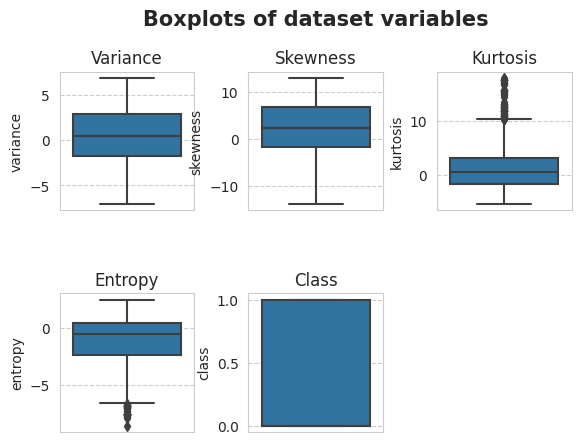

```python
# Box plot and outliers
for i in range(0,5):
  plt.subplot(2,3,i+1)
  sns.boxplot(data=df, y = df[df.columns[i]])
  plt.title(df.columns[i].capitalize())
  plt.subplots_adjust(left=0.1, bottom=0.1, right=0.9, top=0.85, wspace=0.4, hspace=0.6)
plt.suptitle('Boxplots of dataset variables', fontsize=15, fontweight='bold')
plt.show()
```

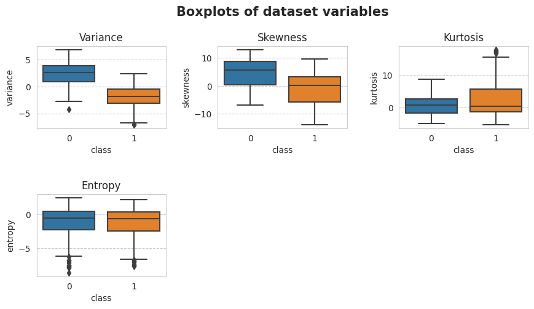

```python
# Box plot per class
plt.figure(figsize=(10,5))
for i in range(0,4):
  plt.subplot(2,3,i+1)
  sns.boxplot(data=df, x='class', y = df[df.columns[i]])
  plt.title(df.columns[i].capitalize())
  plt.subplots_adjust(left=0.1, bottom=0.1, right=0.9, top=0.85, wspace=0.4, hspace=0.8)
plt.suptitle('Boxplots of dataset variables', fontsize=15, fontweight='bold')
plt.show()
```

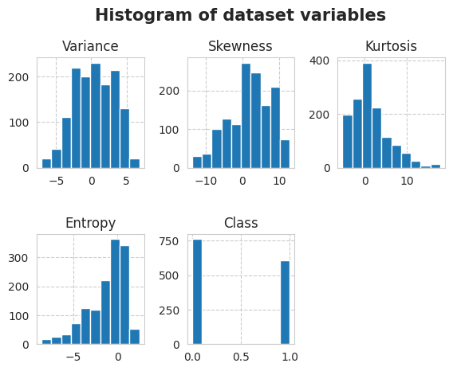

```python
# Histogram for all dataset variables
for i in range(0,5):
  plt.subplot(2,3,i+1)
  plt.hist(df[df.columns[i]])
  plt.title(df.columns[i].capitalize())
  plt.subplots_adjust(left=0.1, bottom=0.1, right=0.9, top=0.85, wspace=0.4, hspace=0.6)
plt.suptitle('Histogram of dataset variables', fontsize=15, fontweight='bold')
plt.show()
```

[output not shown]

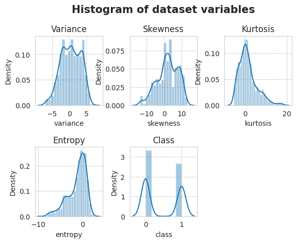

```python
# Distribution for all dataset variables
for i in range(0,5):
  plt.subplot(2,3,i+1)
  sns.distplot(df[df.columns[i]])
  plt.title(df.columns[i].capitalize())
  plt.subplots_adjust(left=0.1, bottom=0.1, right=0.9, top=0.85, wspace=0.4, hspace=0.6)
plt.suptitle('Histogram of dataset variables', fontsize=15, fontweight='bold')
plt.show()
```

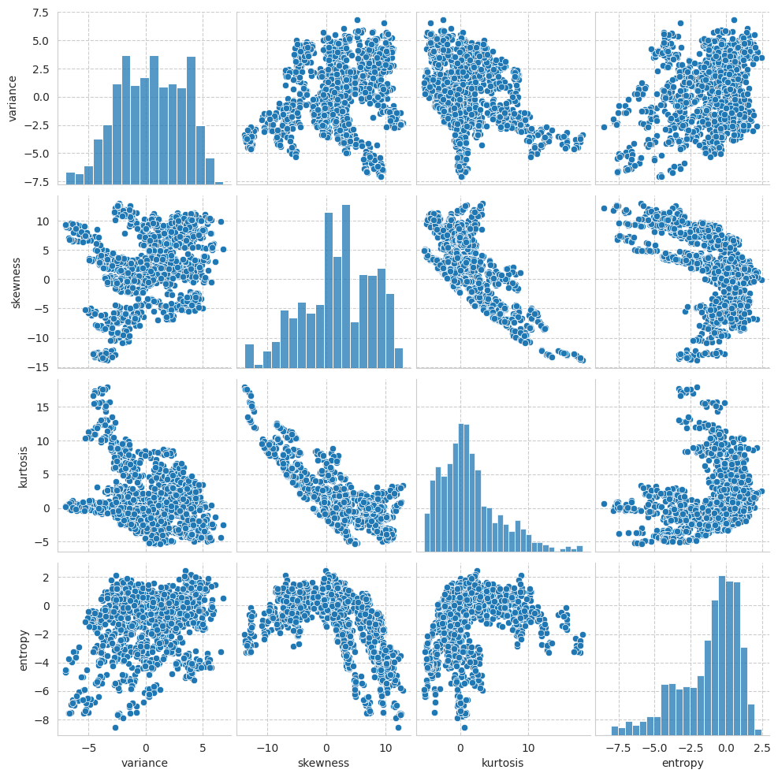

```python
# Pair plot
sns.pairplot(df.loc[:, df.columns !='class'])
sns.set_style("whitegrid", {'grid.linestyle': '--'})
```

```python
# How many datapoints per class in our data
class_0 = df[df['class']==0]['class'].count()
class_1 = df[df['class']==1]['class'].count()

classes = np.array([class_0,class_1])
classes
```

```
array([762, 610])
```

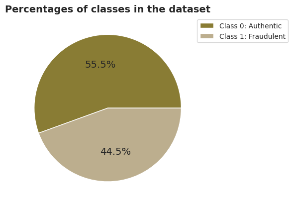

```python
# Pie chart for classes in our data
labels = ['Class 0: Authentic','Class 1: Fraudulent']
plt.pie(classes, autopct='%1.1f%%', colors = ['#897C34', '#BCAE8E'], textprops={'fontsize': 14})
plt.title('Percentages of classes in the dataset', fontsize=14, fontweight='bold')
plt.legend(bbox_to_anchor=(1.5, 1), labels = labels, loc='best')
plt.show()
```

```
(1348, 5)
(1372, 5)
-24
```

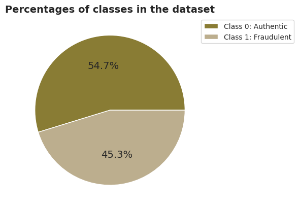

```python
df1 = df.drop_duplicates()
print(df1.shape)
print(df.shape)
print(df1.shape[0]-df.shape[0])
# How many datapoints per class in our data
class_0 = df1[df1['class']==0]['class'].count()
class_1 = df1[df1['class']==1]['class'].count()

classes = np.array([class_0,class_1])
classes

# Pie chart for classes in our data
labels = ['Class 0: Authentic','Class 1: Fraudulent']
plt.pie(classes, autopct='%1.1f%%', colors = ['#897C34', '#BCAE8E'], textprops={'fontsize': 14})
plt.title('Percentages of classes in the dataset', fontsize=14, fontweight='bold')
plt.legend(bbox_to_anchor=(1.5, 1), labels = labels, loc='best')
plt.show()
```

The pie plot for the variable class shows that the dataset contains more auhtentic bank notes data than inauthentic ones.

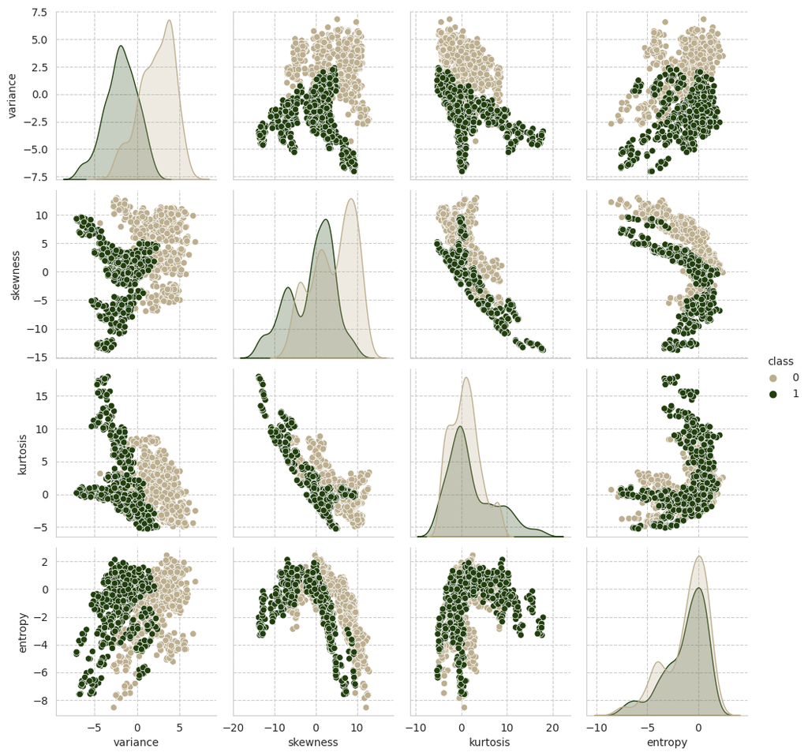

```python
# Exploring variables by class (as a different color in the scatter plot)
sns.pairplot(df, hue='class', palette = ['#BCAE8E', '#213F0D'])
sns.set_style("whitegrid", {'grid.linestyle': '--'})
```

```python
corr = df.corr()
corr
```

|  | variance | skewness | kurtosis | entropy | class |
| --- | --- | --- | --- | --- | --- |
| variance | 1.000000 | 0.264026 | -0.380850 | 0.276817 | -0.724843 |
| skewness | 0.264026 | 1.000000 | -0.786895 | -0.526321 | -0.444688 |
| kurtosis | -0.380850 | -0.786895 | 1.000000 | 0.318841 | 0.155883 |
| entropy | 0.276817 | -0.526321 | 0.318841 | 1.000000 | -0.023424 |
| class | -0.724843 | -0.444688 | 0.155883 | -0.023424 | 1.000000 |

```python
corr[abs(corr)>0.5]
```

|  | variance | skewness | kurtosis | entropy | class |
| --- | --- | --- | --- | --- | --- |
| variance | 1.000000 | NaN | NaN | NaN | -0.724843 |
| skewness | NaN | 1.000000 | -0.786895 | -0.526321 | NaN |
| kurtosis | NaN | -0.786895 | 1.000000 | NaN | NaN |
| entropy | NaN | -0.526321 | NaN | 1.000000 | NaN |
| class | -0.724843 | NaN | NaN | NaN | 1.000000 |

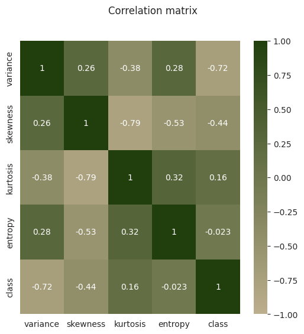

```python
# Correlation matrix
from matplotlib.colors import LinearSegmentedColormap

plt.figure(figsize=(6,6))
sns.heatmap(corr, cmap=LinearSegmentedColormap.from_list('custom_cmap', ['#BCAE8E', '#213F0D']), annot=True, vmax=1, vmin=-1)
plt.suptitle("Correlation matrix")
plt.show()
```

### Results from plot

- Only 6 strongly correlated variables (6 regions shown in the graph) and they are all negatively correlated: kurtosis and skewness, then there is class and variance, then lastly the entropy and skewness.
- However, looking back at the previous graph, entropy and skewness look like they are best represented by a polynomial of negative coefficient rather than a linear relation.

## **4. Data Pre-processing**

In this step, Standardizing dataset will allow for the transformation of attributes to having a mean of 0 and a standard deviation of 1.

```python
df.values
df.values.dtype
df.values.shape
df.values.size
```

```
6860
```

```python
# Inputs (Independent variables)
X = df.values[:,:4] # 4 variables: 'variance', 'skewness', 'kurtosis', and 'entropy'
# Output (Dependent variable)
Y = df.values[:,4] # the 'class' (integer - binary 0, 1)
```

```python
from sklearn.preprocessing import StandardScaler
scaler = StandardScaler().fit(X)
rescaledX = scaler.fit_transform(X)
rescaledX
```

```
array([[ 1.12180565,  1.14945512, -0.97597007,  0.35456135],
       [ 1.44706568,  1.06445293, -0.89503626, -0.12876744],
       [ 1.20780971, -0.77735215,  0.12221838,  0.61807317],
       ...,
       [-1.47235682, -2.62164576,  3.75901744, -0.75488418],
       [-1.40669251, -1.75647104,  2.552043  , -0.04315848],
       [-1.04712236, -0.43982168,  0.29861555,  1.1364645 ]])
```

```python
scaler = StandardScaler()
scaler.fit(pd.DataFrame(X))
X = pd.DataFrame(scaler.transform(X), columns = df.columns[0:4])

print(X.mean()) # either 0 or values very close to 0
print(X.std()) # around 1
X # compare X with df: values have changed
```

```
variance    0.000000e+00
skewness    4.143106e-17
kurtosis    1.035777e-17
entropy    -4.919939e-17
dtype: float64
variance    1.000365
skewness    1.000365
kurtosis    1.000365
entropy     1.000365
dtype: float64
```

|  | variance | skewness | kurtosis | entropy |
| --- | --- | --- | --- | --- |
| 0 | 1.121806 | 1.149455 | -0.975970 | 0.354561 |
| 1 | 1.447066 | 1.064453 | -0.895036 | -0.128767 |
| 2 | 1.207810 | -0.777352 | 0.122218 | 0.618073 |
| 3 | 1.063742 | 1.295478 | -1.255397 | -1.144029 |
| 4 | -0.036772 | -1.087038 | 0.736730 | 0.096587 |
| ... | ... | ... | ... | ... |
| 1367 | -0.009711 | -0.097693 | -0.660962 | 0.300996 |
| 1368 | -0.641313 | -1.158984 | 1.179023 | 0.730127 |
| 1369 | -1.472357 | -2.621646 | 3.759017 | -0.754884 |
| 1370 | -1.406693 | -1.756471 | 2.552043 | -0.043158 |
| 1371 | -1.047122 | -0.439822 | 0.298616 | 1.136464 |

1372 rows × 4 columns

```python
df
```

|  | variance | skewness | kurtosis | entropy | class |
| --- | --- | --- | --- | --- | --- |
| 0 | 3.62160 | 8.66610 | -2.8073 | -0.44699 | 0 |
| 1 | 4.54590 | 8.16740 | -2.4586 | -1.46210 | 0 |
| 2 | 3.86600 | -2.63830 | 1.9242 | 0.10645 | 0 |
| 3 | 3.45660 | 9.52280 | -4.0112 | -3.59440 | 0 |
| 4 | 0.32924 | -4.45520 | 4.5718 | -0.98880 | 0 |
| ... | ... | ... | ... | ... | ... |
| 1367 | 0.40614 | 1.34920 | -1.4501 | -0.55949 | 1 |
| 1368 | -1.38870 | -4.87730 | 6.4774 | 0.34179 | 1 |
| 1369 | -3.75030 | -13.45860 | 17.5932 | -2.77710 | 1 |
| 1370 | -3.56370 | -8.38270 | 12.3930 | -1.28230 | 1 |
| 1371 | -2.54190 | -0.65804 | 2.6842 | 1.19520 | 1 |

1372 rows × 5 columns

```python
from sklearn.model_selection import train_test_split
# validation size conventionally being set to 20%
validation_size = 0.2
seed = 7
Xtrain, Xvalidation, Ytrain, Yvalidation = train_test_split(X, Y, test_size = validation_size, random_state=seed)
print(Y)
print(Xtrain.shape)
print(Xvalidation.shape)
```

```
[0. 0. 0. ... 1. 1. 1.]
(1097, 4)
(275, 4)
```

# **5. Logistic Regression**

```python
#Logistic Regression
from sklearn.linear_model import LogisticRegression
from sklearn.model_selection import KFold
models = []
models.append(('LR', LogisticRegression()))
models
```

```
[('LR', LogisticRegression())]
```

```python
from sklearn.model_selection import KFold
from sklearn.model_selection import cross_val_score
results = []
names = []
for name, model in models:
  kfold = KFold(n_splits = 10, random_state = seed, shuffle=True)
  cv_results = cross_val_score(model, Xtrain, Ytrain, cv=kfold, scoring='accuracy')
  results.append(cv_results)
  names.append(name)
  print("%s = %f (%f)" % (name, cv_results.mean(), cv_results.std()))
```

```
LR = 0.981793 (0.011493)
```

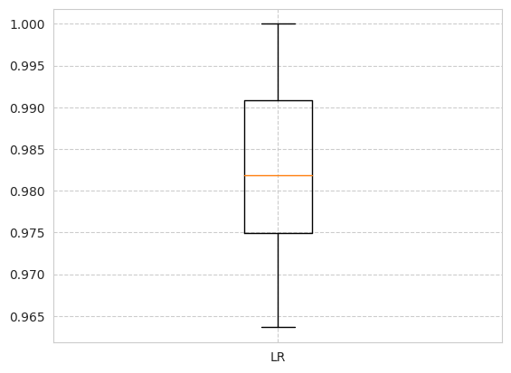

```python
import matplotlib.pyplot as plt
plt.boxplot(results, labels = names)
plt.show()
```

```python
from sklearn.metrics import classification_report
from sklearn.metrics import confusion_matrix
from sklearn.metrics import accuracy_score

LogiReg = LogisticRegression()
LogiReg.fit(Xtrain, Ytrain)
predictions = LogiReg.predict(Xvalidation)

print(accuracy_score(Yvalidation,predictions))
print(confusion_matrix(Yvalidation,predictions))
print(classification_report(Yvalidation,predictions))
```

```
0.9781818181818182
[[152   6]
 [  0 117]]
              precision    recall  f1-score   support

         0.0       1.00      0.96      0.98       158
         1.0       0.95      1.00      0.97       117

    accuracy                           0.98       275
   macro avg       0.98      0.98      0.98       275
weighted avg       0.98      0.98      0.98       275
```

```python
print(Yvalidation)
print(predictions)
```

```
[0. 0. 0. 1. 0. 1. 0. 0. 1. 1. 0. 0. 1. 0. 0. 0. 1. 0. 1. 1. 1. 1. 1. 0.
 0. 0. 0. 0. 0. 1. 0. 1. 1. 1. 0. 0. 0. 0. 1. 1. 0. 0. 0. 1. 0. 0. 1. 0.
 0. 1. 0. 0. 1. 0. 0. 1. 1. 0. 0. 1. 0. 1. 0. 1. 0. 0. 0. 0. 1. 1. 0. 0.
 1. 1. 0. 0. 0. 0. 0. 0. 1. 0. 1. 0. 0. 0. 0. 1. 0. 1. 0. 0. 0. 0. 0. 1.
 1. 0. 1. 1. 1. 0. 1. 0. 0. 0. 1. 1. 0. 0. 0. 0. 0. 1. 1. 1. 1. 0. 1. 0.
 0. 0. 1. 0. 0. 0. 0. 1. 0. 1. 0. 1. 0. 1. 1. 1. 0. 0. 1. 1. 0. 0. 0. 0.
 1. 1. 0. 0. 0. 0. 0. 1. 0. 0. 0. 0. 1. 0. 0. 0. 0. 1. 1. 0. 0. 0. 0. 1.
 0. 0. 1. 0. 1. 0. 1. 0. 0. 0. 1. 0. 1. 0. 1. 1. 1. 1. 0. 1. 0. 1. 1. 1.
 0. 1. 0. 1. 1. 1. 0. 1. 0. 1. 0. 0. 0. 0. 1. 0. 1. 1. 0. 0. 0. 1. 0. 1.
 1. 0. 0. 1. 1. 0. 1. 0. 0. 1. 1. 0. 1. 0. 1. 1. 1. 1. 1. 0. 1. 0. 1. 1.
 0. 0. 1. 1. 0. 1. 0. 1. 1. 0. 0. 0. 0. 1. 0. 0. 1. 0. 0. 1. 0. 1. 0. 1.
 1. 0. 0. 0. 0. 1. 0. 1. 1. 0. 1.]
[0. 0. 0. 1. 0. 1. 0. 0. 1. 1. 0. 0. 1. 0. 0. 0. 1. 0. 1. 1. 1. 1. 1. 0.
 0. 0. 1. 0. 0. 1. 0. 1. 1. 1. 0. 0. 0. 0. 1. 1. 0. 0. 0. 1. 0. 0. 1. 0.
 0. 1. 0. 1. 1. 0. 0. 1. 1. 0. 0. 1. 0. 1. 0. 1. 0. 0. 0. 0. 1. 1. 0. 0.
 1. 1. 0. 0. 0. 0. 0. 1. 1. 0. 1. 0. 0. 0. 0. 1. 0. 1. 0. 0. 0. 0. 0. 1.
 1. 0. 1. 1. 1. 0. 1. 0. 0. 0. 1. 1. 0. 0. 0. 0. 0. 1. 1. 1. 1. 0. 1. 0.
 0. 0. 1. 0. 0. 0. 0. 1. 0. 1. 0. 1. 0. 1. 1. 1. 0. 0. 1. 1. 0. 0. 0. 0.
 1. 1. 0. 0. 0. 0. 0. 1. 0. 0. 0. 0. 1. 0. 0. 0. 0. 1. 1. 0. 0. 0. 0. 1.
 1. 0. 1. 0. 1. 0. 1. 0. 0. 0. 1. 0. 1. 0. 1. 1. 1. 1. 0. 1. 0. 1. 1. 1.
 0. 1. 0. 1. 1. 1. 0. 1. 0. 1. 0. 0. 0. 0. 1. 0. 1. 1. 0. 0. 0. 1. 0. 1.
 1. 0. 0. 1. 1. 0. 1. 0. 0. 1. 1. 0. 1. 0. 1. 1. 1. 1. 1. 0. 1. 0. 1. 1.
 0. 0. 1. 1. 1. 1. 0. 1. 1. 0. 0. 0. 0. 1. 0. 0. 1. 0. 0. 1. 0. 1. 0. 1.
 1. 0. 1. 0. 0. 1. 0. 1. 1. 0. 1.]
```

```python
# Finalizing the Logistic regression model
from pickle import dump
# Since the Logistic regression leads to a high accuracy, we can change the test size from 20% to a greater value, say 30%.
# test size is now changed from the validation size of 20% to be set to 30%
validation_size = 0.3
Xtrain, Xtest, Ytrain, Ytest = train_test_split(X, Y, test_size = validation_size, random_state=seed)

model = LogisticRegression()
model.fit(Xtrain, Ytrain)

dump(model, open("finalized_LogiReg.sav", "wb"))
```

```python
from pickle import load
loaded_model = load(open("finalized_LogiReg.sav", "rb"))
result = loaded_model.score(Xtest, Ytest)
print('Accuracy = ', result*100)
```

```
Accuracy =  98.30097087378641
```

# Random Forrest Algorithm

```python
validation_size_RFA = 0.3
seed_RFA = 7
XD_Train, XD_Test, YD_Train, YD_Test = train_test_split(X, Y, test_size = validation_size_RFA, random_state=seed_RFA)
print(Y)
print(XD_Train.shape)
print(XD_Test.shape)
```

```
[0. 0. 0. ... 1. 1. 1.]
(960, 4)
(412, 4)
```

```python
from sklearn.ensemble import RandomForestClassifier as rfc
from sklearn.metrics import classification_report, confusion_matrix, accuracy_score

rf_model = rfc(n_estimators=200, random_state=0)

rf_model.fit(XD_Train, YD_Train)
predicted_labels = rf_model.predict(XD_Test)
rf_model.estimators_
len(rf_model.estimators_)
DX = list(df.columns.values)
DX
DX[0:4]
```

```
['variance', 'skewness', 'kurtosis', 'entropy']
```

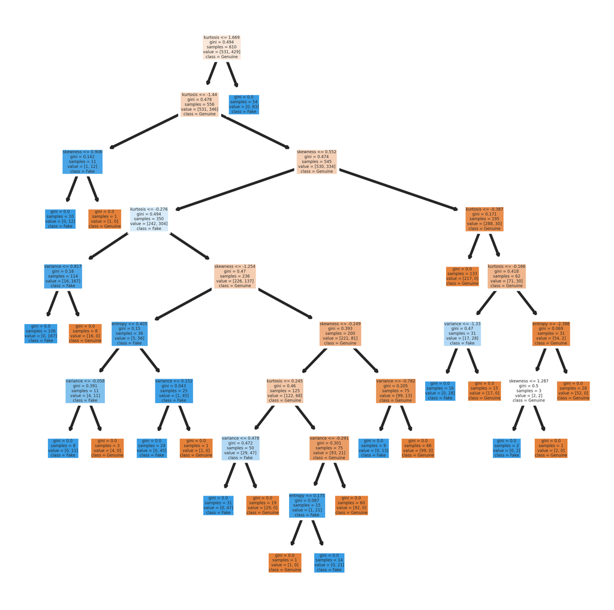

```python
from sklearn import tree

fn=DX[0:4]
#cn = list(X[4])

fig, axes = plt.subplots(nrows = 1,ncols = 1,figsize = (4,4), dpi=800)
tree.plot_tree(rf_model.estimators_[100],
               feature_names = fn,
               class_names=["Genuine", "Fake"],
               filled = True);
#fig.savefig('rf_individualtree.png')
```

```python
print(classification_report(YD_Test, predicted_labels))

#XD_Train, XD_Test, YD_Train, YD_Test
print(confusion_matrix(YD_Test, predicted_labels))

print('Training Accuracy : ',
      accuracy_score(YD_Train,rf_model.predict(XD_Train))*100)
print('Validation Accuracy : ',
      accuracy_score(YD_Test,rf_model.predict(XD_Test))*100)
```

```
              precision    recall  f1-score   support

         0.0       1.00      0.98      0.99       240
         1.0       0.97      0.99      0.98       172

    accuracy                           0.99       412
   macro avg       0.98      0.99      0.99       412
weighted avg       0.99      0.99      0.99       412

[[235   5]
 [  1 171]]
Training Accuracy :  100.0
Validation Accuracy :  98.54368932038835
```

```python
dump(rf_model, open("finalized_rf.sav", "wb"))
```

# SVM

```python
import pandas as pd
from sklearn.svm import SVC
```

```python
X = df.values[:,:4] # 4 variables: 'variance', 'skewness', 'kurtosis', and 'entropy'
Y = df.values[:,4] # the 'class' (integer - binary 0, 1)

scaler = StandardScaler()
scaler.fit(pd.DataFrame(X))
X = pd.DataFrame(scaler.transform(X), columns = df.columns[0:4])
```

```python
X_train, X_test, y_train, y_test = train_test_split(X, Y, test_size=0.3, random_state=123)

# Create the SVM model
model = SVC()

# Train the model
model.fit(X_train, y_train)

# Make predictions
y_pred = model.predict(X_test)

# Evaluate the model
accuracy = model.score(X_test, y_test)
print('Accuracy:', accuracy)
```

```
Accuracy: 1.0
```

[figure not shown]

```python
print("Training Accuracy: ", accuracy_score(y_train, model.predict(X_train)) *100)
print("Validation Accuracy: ", accuracy_score(y_test, model.predict(X_test)) *100)
```

```
Training Accuracy:  100.0
Validation Accuracy:  100.0
```

```python
print(accuracy_score(y_test ,y_pred))
print(confusion_matrix(y_test ,y_pred))
print(classification_report(y_test ,y_pred))
```

```
1.0
[[233   0]
 [  0 179]]
              precision    recall  f1-score   support

         0.0       1.00      1.00      1.00       233
         1.0       1.00      1.00      1.00       179

    accuracy                           1.00       412
   macro avg       1.00      1.00      1.00       412
weighted avg       1.00      1.00      1.00       412
```

```python
dump(rf_model, open("finalized_svm.sav", "wb"))
```

# Conclusion

- SVM was the best algorithm for this dataset.
- The quality of image is critical while generating the dataset.
- The amount of study being done in this sector is growing all the time, and various image processing techniques are being used to produce more accurate results.
- The proposed techniques can be used to extract characteristics from other currencies as well.